# Final Exam

Ty Darnell

December 5, 2018

# 1)

I have not recieved any assistance from anyone in completing this exam.

# Problem 2

```r
load("~/Bios662/Final/final2018q2.RData")
aric=as_tibble(aric)
aric$male=factor(aric$male)
```

## Part a

```r
tab=table(aric$race_aa,aric$center)
tbl = matrix(data=c(182,0,208,236,62,458,0,0), nrow=2, ncol=4, byrow=T)
dimnames(tbl) = list(race_aa=c('0', '1'),center=c('F', 'J','M','W'))
kable(tbl)
```

|  | F | J | M | W |
| --- | --- | --- | --- | --- |
| 0 | 182 | 0 | 208 | 236 |
| 1 | 62 | 458 | 0 | 0 |

```r
(chi2 = chisq.test(tbl, correct=F))
```

```
##
##  Pearson's Chi-squared test
##
## data:  tbl
## X-squared = 959.42, df = 3, p-value < 2.2e-16
```

```r
qchisq(.95, df=3)
```

```
## [1] 7.814728
```

$\alpha =.05$

$H_0: \pi_{ij}=\pi_i \pi_j \quad i=1,2 \ j=1,2,3,4$ (independent, no association)

The null hypothesis is that race and center are independent, thus no association between the two variables

$H_A: \pi_{ij}\neq \pi_i \pi_j$

The alternative hypothesis is that there is an association between race and center.

Using the chi square test for independence, (chi square distribution)

Under $H_0: X^2 \sim \chi^2_{(r-1)(c-1)}$

r=2 c=4 so df=1*3=3

Critical region: $C_{.05}=\{X^2:X^2>\chi^2_{3,.95}=7.815 \}$

$X^2$= 959.4201199

p-value = 1.142784810^{-207}

Since $X^2$ is in critical region, reject $H_0$

Conclude there is an association between race and center.

## Part b

```r
sub=aric%>%select(race_aa,center,il6)
sub$group <- with(sub, interaction(race_aa,center))
groupmean=sub%>%group_by(race_aa,group)%>%summarize(groupmean=mean(il6))
kable(groupmean)
```

| race_aa | group | groupmean |
| --- | --- | --- |
| 0 | 0.F | 2.807088 |
| 0 | 0.M | 3.021731 |
| 0 | 0.W | 2.797585 |
| 1 | 1.F | 4.278065 |
| 1 | 1.J | 3.093515 |

```r
sub$group=factor(sub$group)
```

$Y_{ij}$ is the $j^{th}$ observation in the $i^{th}$ group

$i=1,2$ $j=1,2,3,4$

Assume $Y_{ij} \sim N(\mu_i,\sigma^2)$

Conducting a global anova F-Test to see if there is a difference in the means between the groups

Assumptions:

Homogeneity of variance

Normality and independence of residual error

Linearity

$\alpha=.05$

We have two levels of `race_aa` and 4 levels of `center` which gives us 8 combinations of the two variables. However we have no observations where `race_aa`=0 and `center` = J or `race_aa`=1 and `center` = M or `race_aa`=1 and `center` = W. Thus we only have 5 groups.

$\mu_1$ is the mean IL-6 level of group 1 - `race_aa`=0 `center`=F

$\mu_2$ is the mean of group 2- `race_aa`=0 `center`=M

$\mu_3$ is the mean of group 3- `race_aa`=0 `center`=W

$\mu_4$ is the mean of group 4- `race_aa`=1 `center`=F

$\mu_5$ is the mean of group 5- `race_aa`=1 `center`=J

```r
av <- aov(sub$il6~sub$group)
kable(anova(av))
```

|  | Df | Sum Sq | Mean Sq | F value | Pr(>F) |
| --- | --- | --- | --- | --- | --- |
| sub$group | 4 | 120.1527 | 30.038169 | 3.110612 | 0.0147007 |
| Residuals | 1141 | 11018.2659 | 9.656675 | NA | NA |

```r
(critfval=qf(.95,4,1141))
```

```
## [1] 2.379729
```

$H_0: \mu_1=\mu_2=\dots=\mu_5$

$H_A:$ at least one inequality

$C_{.05}=\{F>F_{4,1141,.95}=2.38\}$

MSR=Mean square regression

MSE = Mean square error

Global F test statistic: $F^*$ = MSR/MSE= 3.11

$F^*>$ critical F value

$3.11>2.38$

Conclusion: Reject $H_0$ since p-value< .05 and test statistic is in the critical region.

Conclude that at least one group has a different il6 mean.

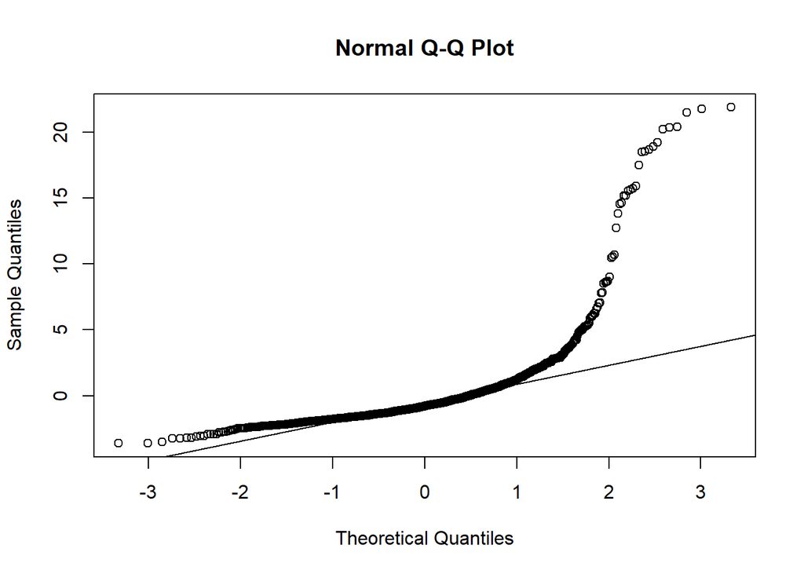

```r
qq1 <- qqnorm(av$residuals); qqline(av$residuals)
```

```r
cor.test(qq1$x,qq1$y)
```

```
##
##  Pearson's product-moment correlation
##
## data:  qq1$x and qq1$y
## t = 40.819, df = 1144, p-value < 2.2e-16
## alternative hypothesis: true correlation is not equal to 0
## 95 percent confidence interval:
##  0.7453345 0.7925757
## sample estimates:
##       cor
## 0.7700083
```

```r
lillie.test(av$residuals)
```

```
##
##  Lilliefors (Kolmogorov-Smirnov) normality test
##
## data:  av$residuals
## D = 0.20465, p-value < 2.2e-16
```

```r
shapiro.test(av$residuals)
```

```
##
##  Shapiro-Wilk normality test
##
## data:  av$residuals
## W = 0.59323, p-value < 2.2e-16
```

The QQ-plot for the residuals from the model suggests that there is departure from normality in the distribution of the residuals.

The result of the Lilliefors KS normality test and the Shapiro-Wilk normality test suggest a departure from normality for the residuals since both p-values are much smaller than alpha so we reject the null hypothesis that the residuals are normally distributed.

In order to determine which means differ from each other we will conduct a pairwise scheffe Anova Test

We have ${5\choose 2}$=10 null and alternative hypotheses represented by i and j each taking values of the 5 groups.

Each $H_0$ is testing if the mean IL-6 levels are equal between two groups

Each $H_A$ is that the mean IL-6 levels are not equal between those two groups

$H_0:\mu_i=\mu_j \quad (i\neq j)$

$H_A: \mu_i \neq \mu_j \quad (i\neq j)$

```r
pairwise=pairw.anova(sub$il6,sub$group,conf.level=.95,method="scheffe")
```

Looking at the table of result from the Scheffe test we have:

```r
kable(pairwise[4])
```

|  | Diff | Lower | Upper | Decision | Adj. P-value |
| --- | --- | --- | --- | --- | --- |
| mu0.F-mu1.F | -1.47098 | -2.88082 | -0.06113 | Reject H0 | 0.035301 |
| mu0.F-mu1.J | -0.28643 | -1.12652 | 0.55367 | FTR H0 | 0.893168 |
| mu1.F-mu1.J | 1.18455 | -0.11287 | 2.48197 | FTR H0 | 0.094772 |
| mu0.F-mu0.M | -0.21464 | -1.18778 | 0.75849 | FTR H0 | 0.976964 |
| mu1.F-mu0.M | 1.25633 | -0.13094 | 2.64361 | FTR H0 | 0.099698 |
| mu1.J-mu0.M | 0.07178 | -0.72986 | 0.87343 | FTR H0 | 0.999289 |
| mu0.F-mu0.W | 0.0095 | -0.93631 | 0.95531 | FTR H0 | 1 |
| mu1.F-mu0.W | 1.48048 | 0.11223 | 2.84872 | Reject H0 | 0.02546 |
| mu1.J-mu0.W | 0.29593 | -0.47231 | 1.06417 | FTR H0 | 0.841967 |
| mu0.M-mu0.W | 0.22415 | -0.68768 | 1.13597 | FTR H0 | 0.965739 |

Conclusion:

Fail to reject $H_0$ for

$(\mu_1,\mu_5)$ $(\mu_1,\mu_2)$ $(\mu_1,\mu_3)$ $(\mu_2,\mu_5)$ $(\mu_2,\mu_4)$ $(\mu_2,\mu_3)$ $(\mu_3,\mu_5)$ $(\mu_4,\mu_5)$

based on the p-values provided in the table which are all $>\alpha$

This means that there is not a statistically signifcant difference between the means of il6 level for each of these pairwise comparisons

Reject $H_0$ for

$(\mu_1,\mu_4)$ $(\mu_3,\mu_4)$

based on the p-values provided in the table which are all $<\alpha$

This means that there is a difference between the means of the il6 levels of these pairwise comparisons.

## Part c

Linear regression model

Assumptions:

1. Linearity: $Y_i = \alpha + \beta X_i + \epsilon_i$
2. Xs are fixed constants
3. $\epsilon_i$ iid $N(0,\sigma^2)$ (homogeneity of variance)

Y=ln(IL6)

X= BMI

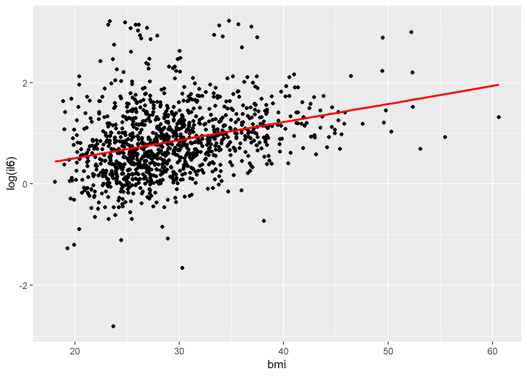

```r
mod1=lm(log(il6)~bmi,aric)
grid=aric%>%data_grid(bmi)%>%add_predictions(mod1)
ggplot(aric,aes(bmi))+geom_point(aes(y=log(il6)))+geom_line(aes(y=pred),data=grid,color="red",size=1)
```

```r
modpluserror=mod1$coefficients[[1]]+mod1$coefficients[[2]]*aric$bmi+mod1$residuals
a=tibble(modpluserror,log(aric$il6))
a
```

```
## # A tibble: 1,146 x 2
##    modpluserror `log(aric$il6)`
##           <dbl>           <dbl>
##  1        0.278           0.278
##  2        0.604           0.604
##  3        0.322           0.322
##  4        1.03            1.03
##  5        0.542           0.542
##  6        1.22            1.22
##  7        0.647           0.647
##  8        0.875           0.875
##  9        0.554           0.554
## 10        0.673           0.673
## # ... with 1,136 more rows
```

Based on the tibble, $Y=\alpha+\beta X+\epsilon$

Thus assumption 1 is satisfied

```r
summary(mod1)
```

```
##
## Call:
## lm(formula = log(il6) ~ bmi, data = aric)
##
## Residuals:
##     Min      1Q  Median      3Q     Max
## -3.4539 -0.4114 -0.0533  0.3250  2.5834
##
## Coefficients:
##              Estimate Std. Error t value Pr(>|t|)
## (Intercept) -0.203368   0.098389  -2.067    0.039 *
## bmi          0.035650   0.003298  10.811   <2e-16 ***
## ---
## Signif. codes:  0 '***' 0.001 '**' 0.01 '*' 0.05 '.' 0.1 ' ' 1
##
## Residual standard error: 0.6553 on 1144 degrees of freedom
## Multiple R-squared:  0.09269,    Adjusted R-squared:  0.0919
## F-statistic: 116.9 on 1 and 1144 DF,  p-value: < 2.2e-16
```

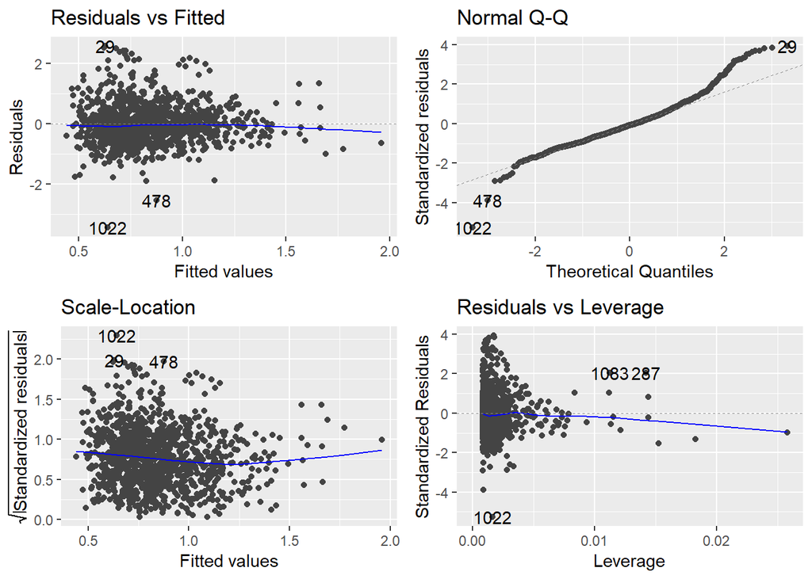

```r
autoplot(mod1)
```

## Part e

```r
female=aric%>%filter(male==0)
males=aric%>%filter(male==1)

modmale=lm(log(il6)~bmi,males)
modfemale=lm(log(il6)~bmi,female)
summary(modmale)
```

```
##
## Call:
## lm(formula = log(il6) ~ bmi, data = males)
##
## Residuals:
##     Min      1Q  Median      3Q     Max
## -3.4834 -0.4824 -0.0692  0.3924  2.5514
##
## Coefficients:
##             Estimate Std. Error t value Pr(>|t|)
## (Intercept) 0.005156   0.239913   0.021 0.982864
## bmi         0.028089   0.008381   3.351 0.000877 ***
## ---
## Signif. codes:  0 '***' 0.001 '**' 0.01 '*' 0.05 '.' 0.1 ' ' 1
##
## Residual standard error: 0.7488 on 420 degrees of freedom
## Multiple R-squared:  0.02605,    Adjusted R-squared:  0.02373
## F-statistic: 11.23 on 1 and 420 DF,  p-value: 0.0008769
```

```r
summary(modfemale)
```

```
##
## Call:
## lm(formula = log(il6) ~ bmi, data = female)
##
## Residuals:
##      Min       1Q   Median       3Q      Max
## -1.90727 -0.37446 -0.05174  0.30899  2.52867
##
## Coefficients:
##              Estimate Std. Error t value Pr(>|t|)
## (Intercept) -0.255125   0.103244  -2.471   0.0137 *
## bmi          0.037491   0.003383  11.083   <2e-16 ***
## ---
## Signif. codes:  0 '***' 0.001 '**' 0.01 '*' 0.05 '.' 0.1 ' ' 1
##
## Residual standard error: 0.5946 on 722 degrees of freedom
## Multiple R-squared:  0.1454, Adjusted R-squared:  0.1442
## F-statistic: 122.8 on 1 and 722 DF,  p-value: < 2.2e-16
```

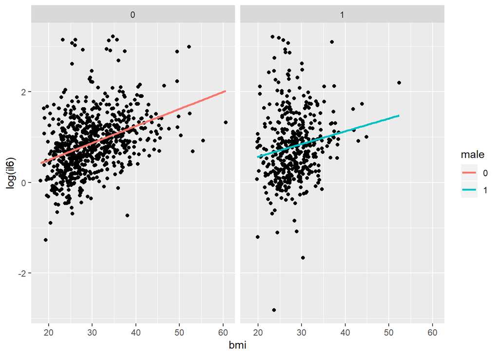

```r
ggplot(aric,aes(x=bmi,y=log(il6)))+geom_point()+geom_smooth(aes(color=male),method="lm",se=F)+facet_wrap(~male)
```

Want to test if the correlation (a measure of linear association) between Bmi and il6 is different between males and females.

```r
(r1=cor(female$bmi,female$il6))
```

```
## [1] 0.2431975
```

```r
(r2=cor(males$bmi,males$il6))
```

```
## [1] 0.04243223
```

```r
zp=function(r){
  z=.5*log((1+r)/(1-r))
  return(z)
}

(z1=zp(r1))
```

```
## [1] 0.2481699
```

```r
(z2=zp(r2))
```

```
## [1] 0.04245773
```

```r
n1=724

n2=422

zs=function(z1,z2,n1,n2){
  z=(z1-z2)/(sqrt((1/(n1-3))+(1/(n2-3))))
  return(z)
}

(zscore=zs(z1,z2,n1,n2))
```

```
## [1] 3.348745
```

$\alpha=.05$

$\rho_1$ = correlation for females

$\rho_2$=correlation for males

$H_0:\rho_1=\rho_2$ (no difference in correlation)

$H_A:\rho_1\neq\rho_2$ (difference in correlation)

r is the sample Pearson product moment correlation coefficient (used to estimate $\rho$)

$r_1=.2431975$

$r_2=.04243223$

$z_1=\dfrac{1}{2}\log\left(\dfrac{1+r_1}{1-r_1}\right)=0.2481698$

$z_2=\dfrac{1}{2}\log\left(\dfrac{1+r_2}{1-r_2}\right)=0.04245772$

$n_1$=sample size females= 724

$n_2$=sample size males =422

$z=\dfrac{z_1-z_2}{\sqrt{(1/n_1-3)+(1/n_2-3)}}=3.348745$

under $H_0: z \sim N(0,1)$

Critical region =$C_{.05}=\{z:z>1.645\}$

$3.348745>1.645$

Conclusion:

Reject $H_0$ since test statistic is in the critical region. Conclude correlation (association) between bmi and il6 does vary by sex.

## Part f

```r
modf=lm(log(il6)~bmi+male+age+hdl_c,aric)
summary(modf)
```

```
##
## Call:
## lm(formula = log(il6) ~ bmi + male + age + hdl_c, data = aric)
##
## Residuals:
##     Min      1Q  Median      3Q     Max
## -3.3645 -0.4190 -0.0609  0.3114  2.7700
##
## Coefficients:
##              Estimate Std. Error t value Pr(>|t|)
## (Intercept) -0.453827   0.235634  -1.926  0.05435 .
## bmi          0.033434   0.003398   9.839  < 2e-16 ***
## male1       -0.065288   0.043461  -1.502  0.13332
## age          0.010288   0.003481   2.956  0.00318 **
## hdl_c       -0.003918   0.001294  -3.028  0.00252 **
## ---
## Signif. codes:  0 '***' 0.001 '**' 0.01 '*' 0.05 '.' 0.1 ' ' 1
##
## Residual standard error: 0.6509 on 1141 degrees of freedom
## Multiple R-squared:  0.1073, Adjusted R-squared:  0.1042
## F-statistic:  34.3 on 4 and 1141 DF,  p-value: < 2.2e-16
```

```r
summary(mod1)
```

```
##
## Call:
## lm(formula = log(il6) ~ bmi, data = aric)
##
## Residuals:
##     Min      1Q  Median      3Q     Max
## -3.4539 -0.4114 -0.0533  0.3250  2.5834
##
## Coefficients:
##              Estimate Std. Error t value Pr(>|t|)
## (Intercept) -0.203368   0.098389  -2.067    0.039 *
## bmi          0.035650   0.003298  10.811   <2e-16 ***
## ---
## Signif. codes:  0 '***' 0.001 '**' 0.01 '*' 0.05 '.' 0.1 ' ' 1
##
## Residual standard error: 0.6553 on 1144 degrees of freedom
## Multiple R-squared:  0.09269,    Adjusted R-squared:  0.0919
## F-statistic: 116.9 on 1 and 1144 DF,  p-value: < 2.2e-16
```

In the new model, the $\beta$ associated with bmi is the change in the expected value of ln(il6) when bmi variable increases by one unit, with all the other X variables being held constant.

coeficient of bmi from part c=0.035650 new coeficient of bmi=0.033434

the coefiecent of bmi decreased by .002216 in the new model. This does not appear to be a substantial change.

## Part g

The multiple $r^2$ from the model from part f is the proportion of variation explained by the model

$r^2=0.1073$

which means that 10.73% of the variation is explained by the model.

## Part h

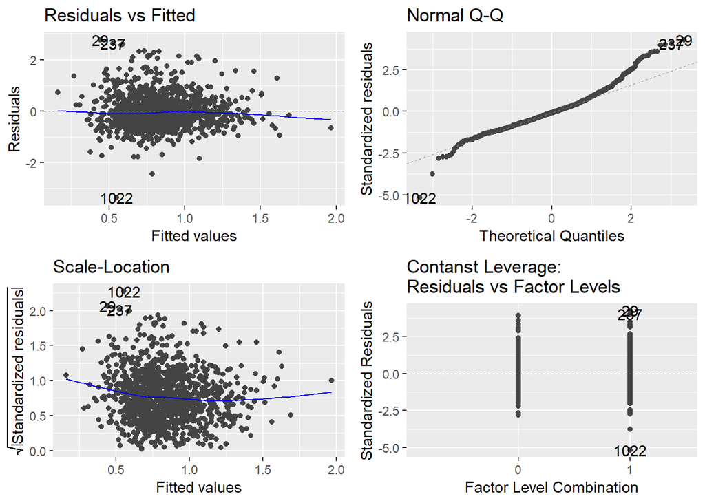

```r
autoplot(modf)
```

There is no obvious pattern in the residuals plotted against the fitted values.

```r
lillie.test(modf$residuals)
```

```
##
##  Lilliefors (Kolmogorov-Smirnov) normality test
##
## data:  modf$residuals
## D = 0.073297, p-value = 6.859e-16
```

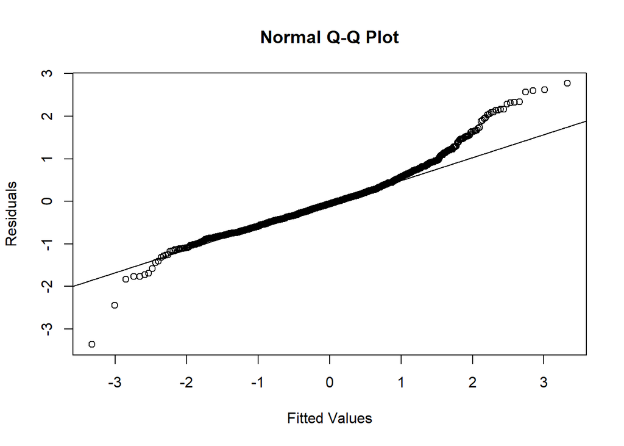

```r
qqnorm(modf$residuals,xlab="Fitted Values",ylab="Residuals"); qqline(modf$residuals)
```

the qqplot for the residuals suggests that there is departure from normality in the tails of the distribution of the residuals.

Looking at the Lilliefor KS normality test, the p-value is much smaller than alpha so we reject the null hypothesis that the residuals are normally distributed, thus suggesting a departure from normality in the residuals and violating the assumption.

```r
df = data.frame(
  male='0',
  bmi=26,
  age=80,
  hdl_c=50)
 kable(predict(modf,df,interval="prediction"))
```

[output not shown]

The 95% prediction interval is exp(-.2492588),exp(2.334465)

which is (0.7793782, 10.3239351)

This can be interpreted as there being a 95% probability that a future observation will be contained within the prediction interval.

I am not very confident in the prediction since an interaction effect was not taken into account in the model when there where potential confounders. Also looking at the qqplot the error terms of the model do not quite appear normally distributed which is a violation of the assumptions.

## Part i

Median of il6=2.24

Median ranks= 573,574

```r
med=aric%>%arrange(il6)%>%mutate(rank=c(1:length(il6)))
med=med%>%mutate(c=diabcase/timediab)
med1=med%>%filter(rank<=573)
med2=med%>%filter(rank>573)
incidence1=med1%>%summarize(incidence=sum(c)*sum(diabcase)/573)
incidence2=med2%>%summarize(incidence=sum(c)*sum(diabcase)/573)
```

Incidence of diabetes for lower half of data= 0.2063462

Incidence of diabetes for upper half of data= 0.3608458

## Part j

```r
med <- med %>% mutate(abovemed=cut(rank, breaks=c(0,573, Inf), labels=c('0','1')))
med=med%>%mutate(agegroup=cut(age,breaks=c(44,49,54,60,65),labels=c('45-49','50-54','55-59','60-64')))
```

```r
 tabstd=med%>%group_by(abovemed,agegroup)%>%summarize(cases=sum(diabcase),N=length(diabcase))
tabstd$w=tabstd$agegroup
 levels(tabstd$w)=c(6,5,4,4)
 tabstd$w=as.numeric(as.character(tabstd$w))
 tabstd=tabstd%>%mutate(p=cases/N)
 kable(tabstd)
```

| abovemed | agegroup | cases | N | w | p |
| --- | --- | --- | --- | --- | --- |
| 0 | 45-49 | 86 | 209 | 6 | 0.4114833 |
| 0 | 50-54 | 72 | 175 | 5 | 0.4114286 |
| 0 | 55-59 | 54 | 122 | 4 | 0.4426230 |
| 0 | 60-64 | 30 | 67 | 4 | 0.4477612 |
| 1 | 45-49 | 97 | 195 | 6 | 0.4974359 |
| 1 | 50-54 | 93 | 154 | 5 | 0.6038961 |
| 1 | 55-59 | 95 | 147 | 4 | 0.6462585 |
| 1 | 60-64 | 50 | 77 | 4 | 0.6493506 |

```r
std1=tabstd%>%filter(abovemed==0)%>%mutate(pw=p*w)
std2=tabstd%>%filter(abovemed==1)%>%mutate(pw=p*w)
stdinc1=std1%>%summarize(std=sum(pw)/19)
stdinc2=std2%>%summarize(std=sum(pw)/19)
std1=std1 %>% mutate(varp1 = p*(1-p)/N)
std2=std2%>%mutate(varp2 = p*(1-p)/N)
adjdiff=stdinc1$std-stdinc2$std
varp1=std1$varp1
varp2=std2$varp2
weights=std1$w
varadjdiff=sum(weights^2*(varp1+varp2))/sum(weights)^2
```

Standardized incidence below the median= 0.4256621

Standardized incidence above the median= 0.5887649

Adjusted Difference = -0.1631028

Variance of Adjusted Difference = 8.999764810^{-4}$\approx .0009$

We want to test whether the incidence of diabetes differs between those with il6 below the median vs above the median. Using a Z-test to determine if the two rates are significantly different.

$\alpha=.05$

$H_0:\pi_{1_{adj}}=\pi_{2_{adj}}$

$H_A:\pi_{1_{adj}}\neq\pi_{2_{adj}}$

Critical Region: $C_{.05}={|Z|>1.96 }

$Z=\dfrac{\text{adjdiff}}{\sqrt{\text{varadjdiff}}}=\dfrac{ -0.1631028}{\sqrt{.0009}}=-5.43676$

-5.436<-1.96

Thus Z is in the critical region so reject $H_0$ and conclude that the incidence of diabetes is significantly higher above the median of il6

## Part k

We are assuming survivial time $T^*$ is greater than 0

Data is right censored so using kaplan meier estimator

Assuming independent censoring

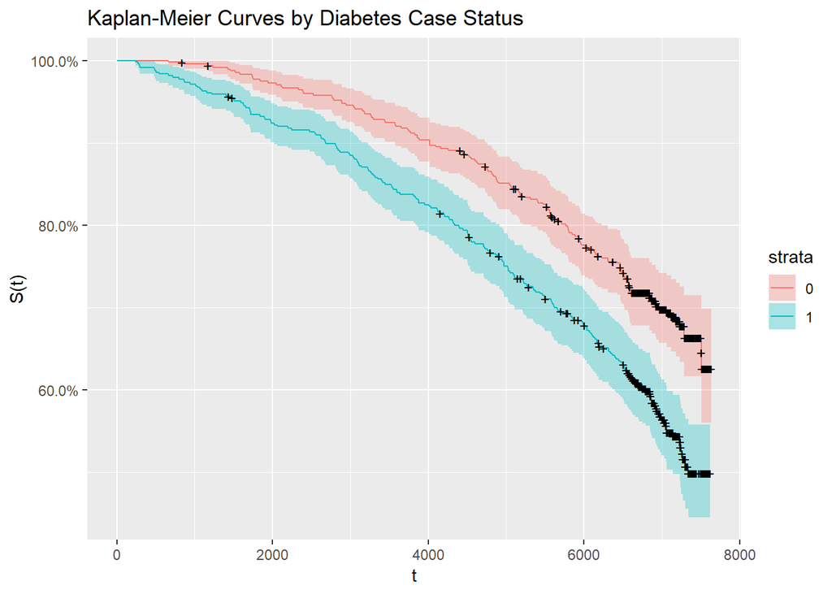

```r
sur=aric%>%arrange(timedeath)
fit <- survfit(Surv(timedeath, dead)~diabcase,data=sur)
autoplot(fit,xlab="t",ylab="S(t)",main = "Kaplan-Meier Curves by Diabetes Case Status")
```

## Part l

```r
summary(fit, times=3650)
```

```
## Call: survfit(formula = Surv(timedeath, dead) ~ diabcase, data = sur)
##
## 181 observations deleted due to missingness
##                 diabcase=0
##         time       n.risk      n.event     survival      std.err
##     3.65e+03     4.38e+02     3.80e+01     9.20e-01     1.24e-02
## lower 95% CI upper 95% CI
##     8.96e-01     9.45e-01
##
##                 diabcase=1
##         time       n.risk      n.event     survival      std.err
##     3.65e+03     4.06e+02     7.90e+01     8.37e-01     1.68e-02
## lower 95% CI upper 95% CI
##     8.05e-01     8.71e-01
```

At t=3650 days since visit 4:

diabcase=0 (not a diabetes case)

survival proportion estimate=.92

95% CI: (.896,.945)

diabcase=1 (diabetes case)

survival proportion estimate = .837

95% CI: (.805,.871)

## Part m

Because there is right censoring an appropriate nonparematric test is the log rank test.

We will use a log rank test to compare the survival functions for the group with diabetes to the group without.

$S_1(t)$ = survival function of group with diabetes

$S_2(t)$ = survival function of group without diabetes

$H_0: S_1(t)=S_2(t)$ for all t

$H_A: S_1(t)\neq S_2(t)$ for at least one t

Under $H_0: X=(O_1-E_1)^2/V_1\sim \chi_1^2$

Critical Region: $C_{.05}=\{X:X>\chi^2_{1,.095}=3.84 \}$

$X=(O_1-E_1)^2/V_1=19.8$

X is in the critical region.

```r
survdiff(Surv(timedeath, dead)~diabcase,data=sur)
```

```
## Call:
## survdiff(formula = Surv(timedeath, dead) ~ diabcase, data = sur)
##
## n=965, 181 observations deleted due to missingness.
##
##              N Observed Expected (O-E)^2/E (O-E)^2/V
## diabcase=0 478      146      188      9.41      19.8
## diabcase=1 487      213      171     10.36      19.8
##
##  Chisq= 19.8  on 1 degrees of freedom, p= 9e-06
```

$p-value \approx .000009<\alpha$

Conclusion:

Reject $H_0$ since X is in the critical region and p-value< $\alpha$, thus $S_1(t)\neq S_2(t)$ for at least one t

Thus conclude that not having diabetes tends to increase survival time.

## Part n

Let $X_1$ be an indicator of being in the diabetes group, X=1 if in group X=0 if not

The proportional hazards model adjusting for age,sex and il6 is:

$\lambda(t)=\lambda_0(t)+\exp(\beta_1 X_1+\beta_2 X_2+\beta_3 X_3+\beta_4 X_4)$

where $X_2$=age $X_3$=sex $X_4$=il6

$\lambda(t)$ is the expected hazard at time t

$\lambda_0$ is the baseline hazard and represents the hazard when all of the predictors are equal to 0.

$e^{\beta}$ is the hazard ratio comparing the group with diabetes to the group without diabetes

Assume:

1. Hazards ratio is independent of time
2. The hazard curves for the two groups are proportional and do not cross

$\alpha=.05$

$\beta$ is the coeficient for diabcase

Want to test :

$H_0:\beta=0$

$H_A:\beta \neq 0$

p-value for $\beta$=0.000458

since p-value <$\alpha$

reject $H_0$ and we conclude that survival differs significantly between the two groups, with the group without diabetes having a significantly beter survival.

Estimate for harzard ratio for group with diabetes relative to group without= 1.458833

This means that the diabetes group has an increased the risk of death relative to the group with out diabetes of 45.9%

```r
coxph(Surv(timedeath, dead)~ diabcase+age+male+il6,sur)
```

```
## Call:
## coxph(formula = Surv(timedeath, dead) ~ diabcase + age + male +
##     il6, data = sur)
##
##              coef exp(coef) se(coef)     z        p
## diabcase 0.377637  1.458833 0.107776 3.504 0.000458
## age      0.094203  1.098783 0.009477 9.940  < 2e-16
## male1    0.331547  1.393121 0.106636 3.109 0.001876
## il6      0.036363  1.037032 0.014883 2.443 0.014555
##
## Likelihood ratio test=134.3  on 4 df, p=< 2.2e-16
## n= 965, number of events= 359
##    (181 observations deleted due to missingness)
```

## Part o

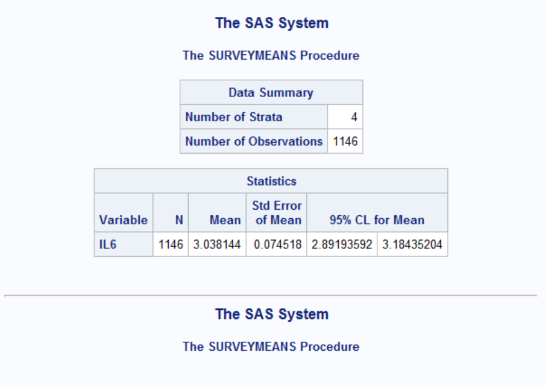

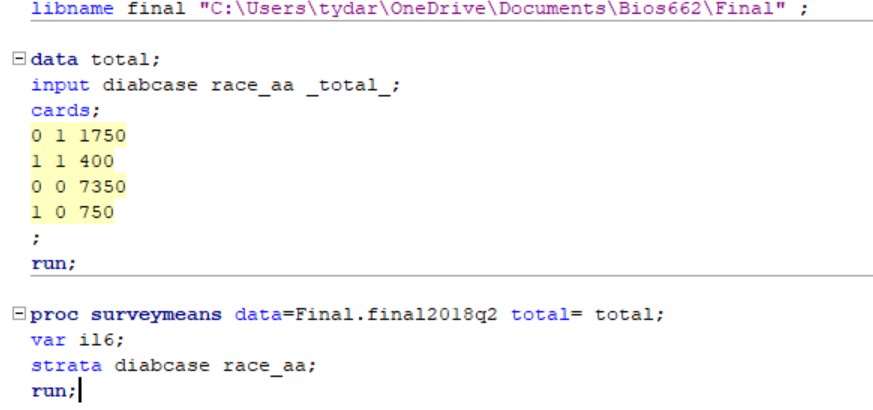

Estimate for mean il6 level= 3.038144

95% CI for mean (2.89193,3.18435)